# Exercise Data

The data used in this fit only included the time averaged data for each window, since these contained overall features of the time varying data. All of these features were then investigated to show how the class of exercise depended on each of these by investigating the correlation between each of the variables and the class of exercise. This cut the number of features to 58, which was still relatively high, so the model used was the random forest method. This was used with no pre-processing, since this gave the highest accuracy against the data. This was cross-validated using repeated k-fold cross validation with k=10. The function used to train the data was

```
 modFit<-train(classe~.,data=training,method="rf",tuneGrid=expand.grid(mtry=5, ntree=500), trControl = trainControl(method = "repeatedcv",number=10,repeats=3))
```

The tuning of the parameters for ‘rf’ was found to converge on accuracy with the training set at mtry=5 (see plot below) and ntrees=500, where mtry is the number of variables randomly sampled as candidates at each split and ntrees is the number of trees to grow.

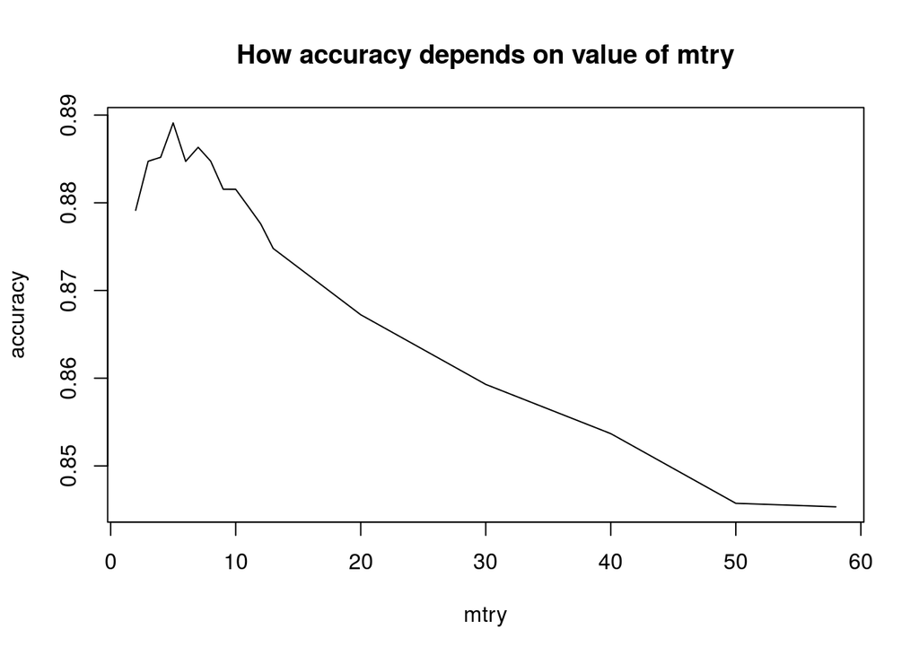

The final confusion matrix and accuracy for the data set using these optimum values were for all samples

```
    Accuracy     Kappa    Resample
1  0.9166667 0.8942826 Fold01.Rep1
2  0.9156627 0.8932378 Fold02.Rep1
3  0.9294118 0.9103376 Fold03.Rep1
4  0.8571429 0.8194842 Fold04.Rep1
5  0.8690476 0.8333333 Fold05.Rep1
6  0.8690476 0.8333333 Fold06.Rep1
7  0.9166667 0.8942256 Fold07.Rep1
8  0.9036145 0.8775134 Fold08.Rep1
9  0.8470588 0.8066830 Fold09.Rep1
10 0.8795181 0.8469200 Fold10.Rep1
11 0.8915663 0.8621262 Fold01.Rep2
12 0.8928571 0.8637592 Fold02.Rep2
13 0.8554217 0.8158625 Fold03.Rep2
14 0.9058824 0.8811397 Fold04.Rep2
```

[output cut: 16 more lines]

And averaged over all samples

[output not shown]